# simpleRegress

Abel Jacobo Perez

11-02-2021

## Introduction

We are comparing the variables Chest and the variable NECK to see what variable is better at determining length.

## make a simple regression model

```r
bears <- read.csv(file="BEARS.csv",header = TRUE)
```

## Model LENGTH ~ NECK

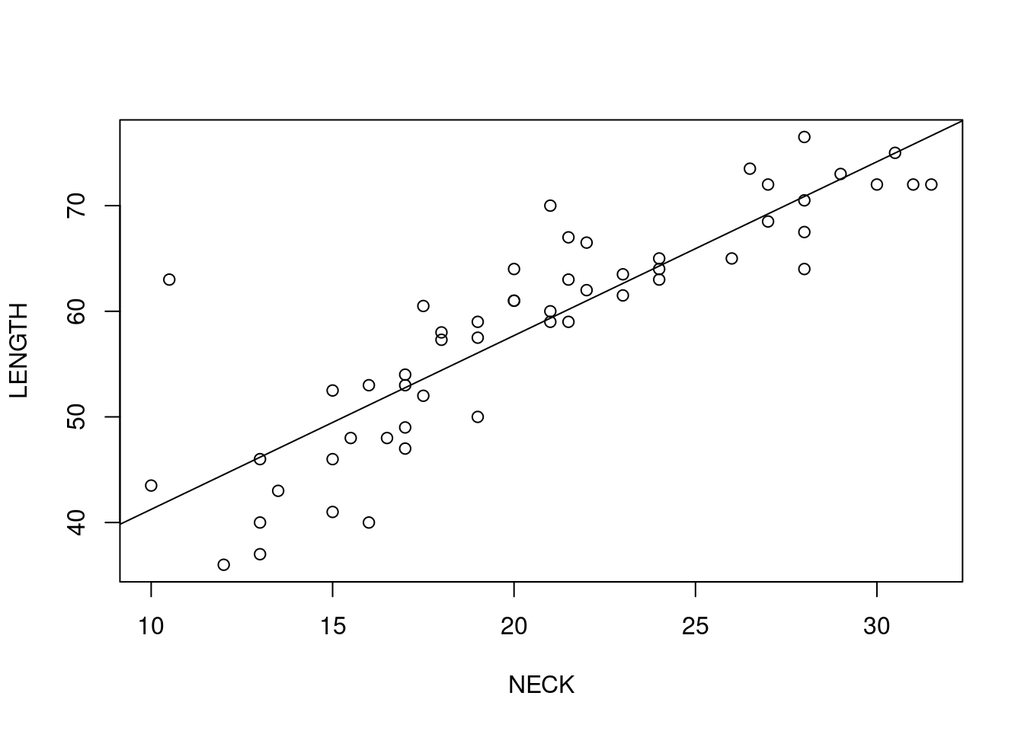

```r
simp <- lm(LENGTH~NECK,data=bears)
plot(LENGTH~NECK,data=bears)
abline(simp)
```

```r
summary.lm(simp)
```

```
##
## Call:
## lm(formula = LENGTH ~ NECK, data = bears)
##
## Residuals:
##      Min       1Q   Median       3Q      Max
## -11.1204  -3.4478  -0.0822   2.8737  20.9300
##
## Coefficients:
##             Estimate Std. Error t value Pr(>|t|)
## (Intercept)  24.7920     2.7886    8.89 5.13e-12 ***
## NECK          1.6455     0.1309   12.57  < 2e-16 ***
## ---
## Signif. codes:  0 '***' 0.001 '**' 0.01 '*' 0.05 '.' 0.1 ' ' 1
##
## Residual standard error: 5.376 on 52 degrees of freedom
## Multiple R-squared:  0.7524, Adjusted R-squared:  0.7476
## F-statistic:   158 on 1 and 52 DF,  p-value: < 2.2e-16
```

Neck as variable for determining a bears length had adjusted R square score of 0.7476

The scatter plot shows that as Neck Size goes up,length does as well,thus Neck size is a good predictor to determine length of the bear.

## now predict the length of a bear who has a neck of 17, 22 and 26

```r
new <- data.frame(NECK=c(17,22,26))
predict(simp,new)
```

```
##        1        2        3
## 52.76592 60.99353 67.57562
```

```r
predict(simp,new,se.fit=TRUE,interval = "prediction")
```

```
## $fit
##        fit      lwr      upr
## 1 52.76592 41.83905 63.69279
## 2 60.99353 50.10004 71.88702
## 3 67.57562 56.59520 78.55605
##
## $se.fit
##         1         2         3
## 0.8670856 0.7556053 1.0213610
##
## $df
## [1] 52
##
## $residual.scale
## [1] 5.375861
```

## Numerical summary

```r
cor(bears$LENGTH,bears$NECK)
```

```
## [1] 0.8673985
```

The correlation coefficient

## Surely there is another variable that can better predict LENGTH than NECK. Find one and compare its performance to that of neck by it value of Adjusted-Rsquared (bigger is better).

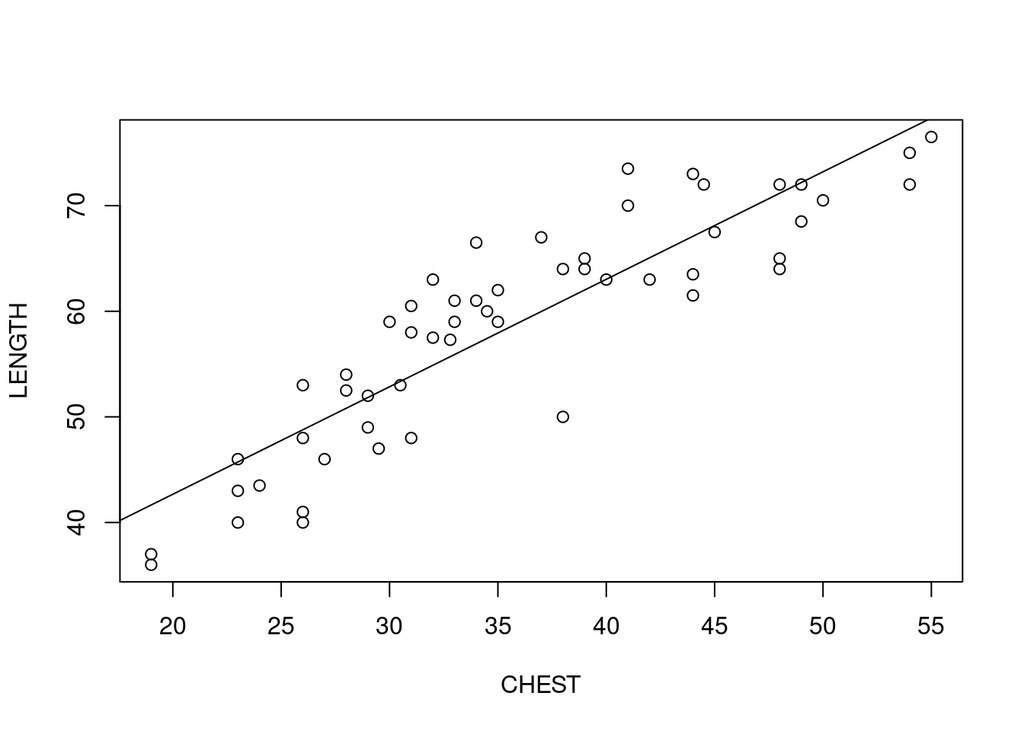

```r
simp <- lm(LENGTH~CHEST,data=bears)
plot(LENGTH~CHEST,data=bears)
abline(simp)
```

```r
summary.lm(simp)
```

```
##
## Call:
## lm(formula = LENGTH ~ CHEST, data = bears)
##
## Residuals:
##      Min       1Q   Median       3Q      Max
## -10.9950  -3.6672   0.0668   3.8389   9.5757
##
## Coefficients:
##             Estimate Std. Error t value Pr(>|t|)
## (Intercept) 22.32388    2.67328   8.351 3.57e-11 ***
## CHEST        1.01766    0.07255  14.027  < 2e-16 ***
## ---
## Signif. codes:  0 '***' 0.001 '**' 0.01 '*' 0.05 '.' 0.1 ' ' 1
##
## Residual standard error: 4.939 on 52 degrees of freedom
## Multiple R-squared:  0.791,  Adjusted R-squared:  0.7869
## F-statistic: 196.7 on 1 and 52 DF,  p-value: < 2.2e-16
```

CHEST as variable for determining a bears length had adjusted R square score of 0.7869

The scatter plot shows that as CHEST Size goes up,length does as well,thus CHEST size is a good predictor to determine the length of a bear.

## Numerical summary

```r
cor(bears$LENGTH,bears$CHEST)
```

```
## [1] 0.8893561
```

The correlation coefficient

## conclusion

CHEST has an adjusted r Squared score of 0.7869 while NECK had an adjust r Squared score of 0.7476.

Chest is a better predictor of length than neck is because the adjusted R squared of the fit for CHEST was larger than the adjusted R squared of the fit for NECK.